# Group 1 DW Team Project - Final

## This is the Submission of Data Wrangling Team Project - Group 1 - Part 1

### Topic: Inspecting, Cleaning and Re-structuring of the eCommerce1c Dataset for the Statistical Analysis and Modelling

```python
## setting up - import the necessary packages ##
import os
#import cv2
import matplotlib
import matplotlib.pyplot as plt
import matplotlib.image as mpimg
import seaborn as sns
import numpy as np
import matplotlib as mpl
import matplotlib.pyplot as plt
import pandas as pd
import seaborn as sb
import matplotlib.pyplot as plt
import matplotlib.tri as mtri
# import missingno as missno
from matplotlib import rcParams
from matplotlib import pyplot as plt
from mpl_toolkits.mplot3d import Axes3D
from scipy import stats
from matplotlib import cm
#from pandas_profiling import ProfileReport
os.getcwd()

os.chdir('C:\\Users\\wooo_\\OneDrive\\Desktop\\SUTD Notes\\Data Wrangling with Programming\\Group Project\\Large Dataset (Group1)')

#os.getcwd()
```

### The original Dataset

```python
## Read the eCommerce Dataset

Df1 = pd.read_csv("eCommerceDataset1.csv", header=0)
```

# Inspecting the dataset

```python
Df1.head()
```

|  | item_id | status | created_at | sku | price_usd | qty_ordered | increment_id | category_name_1 | sales_commission_code | adj_usd | payment_method | Working_Date | B_Status | Year | Month | Customer_Since | M-Y | FY | Customer_ID |
| --- | --- | --- | --- | --- | --- | --- | --- | --- | --- | --- | --- | --- | --- | --- | --- | --- | --- | --- | --- |
| 0 | 211131 | complete | 7/1/2016 | kreations_YI 06-L | 11.63 | 1 | 100147443 | Women's Fashion | \N | 0.0 | cod | 7/1/2016 | Valid | 2016 | 7 | 2016-7 | Jul-16 | FY17 | 1.0 |
| 1 | 211133 | canceled | 7/1/2016 | kcc_Buy 2 Frey Air Freshener & Get 1 Kasual Bo... | 1.43 | 1 | 100147444 | Beauty & Grooming | \N | 0.0 | cod | 7/1/2016 | Gross | 2016 | 7 | 2016-7 | Jul-16 | FY17 | 2.0 |
| 2 | 324257 | canceled | 11/25/2016 | RS_Habshi Halwa Tin | 1.61 | 1 | 100222998 | Soghaat | \N | 0.0 | jazzvoucher | 11/25/2016 | Gross | 2016 | 11 | 2016-7 | Nov-16 | FY17 | 2.0 |
| 3 | 211134 | canceled | 7/1/2016 | Ego_UP0017-999-MR0 | 14.62 | 1 | 100147445 | Women's Fashion | \N | 0.0 | cod | 7/1/2016 | Gross | 2016 | 7 | 2016-7 | Jul-16 | FY17 | 3.0 |
| 4 | 473369 | complete | 5/19/2017 | BT_BT-422 | 3.16 | 1 | 100306394 | Men's Fashion | \N | 0.0 | cod | 5/19/2017 | Net | 2017 | 5 | 2016-7 | May-17 | FY17 | 3.0 |

```python
Df1.tail()
```

|  | item_id | status | created_at | sku | price_usd | qty_ordered | increment_id | category_name_1 | sales_commission_code | adj_usd | payment_method | Working_Date | B_Status | Year | Month | Customer_Since | M-Y | FY | Customer_ID |
| --- | --- | --- | --- | --- | --- | --- | --- | --- | --- | --- | --- | --- | --- | --- | --- | --- | --- | --- | --- |
| 584519 | 804621 | canceled | 3/27/2018 | OTHPCB5AB351ED6A8F2 | 29.83 | 2 | 100496269 | Others | NaN | 0.0 | Easypay | 3/27/2018 | Gross | 2018 | 3 | NaN | Mar-18 | FY18 | NaN |
| 584520 | 805750 | canceled | 3/27/2018 | OTHPCB5AB351ECC7118 | 2.98 | 2 | 100497359 | Others | NaN | 0.0 | Easypay | 3/27/2018 | Gross | 2018 | 3 | NaN | Mar-18 | FY18 | NaN |
| 584521 | 807010 | canceled | 3/27/2018 | OTHPCB5AB351EEC46EC | 2.98 | 4 | 100498582 | Others | NaN | 0.0 | Easypay | 3/27/2018 | Gross | 2018 | 3 | NaN | Mar-18 | FY18 | NaN |
| 584522 | 808287 | order_refunded | 3/27/2018 | MEFKAR5A7C138CE9EBD-L | 6.21 | 1 | 100499821 | Men's Fashion | NaN | 0.0 | cod | 3/27/2018 | Valid | 2018 | 3 | NaN | Mar-18 | FY18 | NaN |
| 584523 | 814174 | canceled | 3/28/2018 | OTHPCB5ABB207673754 | 11.93 | 5 | 100505460 | Others | NaN | 0.0 | Easypay | 3/28/2018 | Gross | 2018 | 3 | NaN | Mar-18 | FY18 | NaN |

```python
## Check Df attributes ##
print(Df1.columns)
print("\n", Df1.shape)
print("\n", Df1.index)
print("\n", Df1.values)
```

```
Index(['item_id', 'status', 'created_at', 'sku', 'price_usd', 'qty_ordered',
       'increment_id', 'category_name_1', 'sales_commission_code', 'adj_usd',
       'payment_method', 'Working_Date', 'B_Status', 'Year', 'Month',
       'Customer_Since', 'M-Y', 'FY', 'Customer_ID'],
      dtype='object')

 (584524, 19)

 RangeIndex(start=0, stop=584524, step=1)

 [[211131 'complete' '7/1/2016' ... 'Jul-16' 'FY17' 1.0]
 [211133 'canceled' '7/1/2016' ... 'Jul-16' 'FY17' 2.0]
 [324257 'canceled' '11/25/2016' ... 'Nov-16' 'FY17' 2.0]
 ...
 [807010 'canceled' '3/27/2018' ... 'Mar-18' 'FY18' nan]
 [808287 'order_refunded' '3/27/2018' ... 'Mar-18' 'FY18' nan]
 [814174 'canceled' '3/28/2018' ... 'Mar-18' 'FY18' nan]]
```

# An overview of the dataframe 1, Df1

## Overall data looks very clean. But more in-depth cleaning is required:

```python
Df1.info()
```

```
<class 'pandas.core.frame.DataFrame'>
RangeIndex: 584524 entries, 0 to 584523
Data columns (total 19 columns):
 #   Column                 Non-Null Count   Dtype
---  ------                 --------------   -----
 0   item_id                584524 non-null  int64
 1   status                 584509 non-null  object
 2   created_at             584524 non-null  object
 3   sku                    584504 non-null  object
 4   price_usd              584524 non-null  float64
 5   qty_ordered            584524 non-null  int64
 6   increment_id           584524 non-null  object
 7   category_name_1        584360 non-null  object
 8   sales_commission_code  447349 non-null  object
 9   adj_usd                584524 non-null  float64
 10  payment_method         584524 non-null  object
 11  Working_Date           584524 non-null  object
 12  B_Status               584524 non-null  object
 13  Year                   584524 non-null  int64
 14  Month                  584524 non-null  int64
 15  Customer_Since         584513 non-null  object
 16  M-Y                    584524 non-null  object
 17  FY                     584524 non-null  object
 18  Customer_ID            584513 non-null  float64
dtypes: float64(3), int64(4), object(12)
memory usage: 84.7+ MB
```

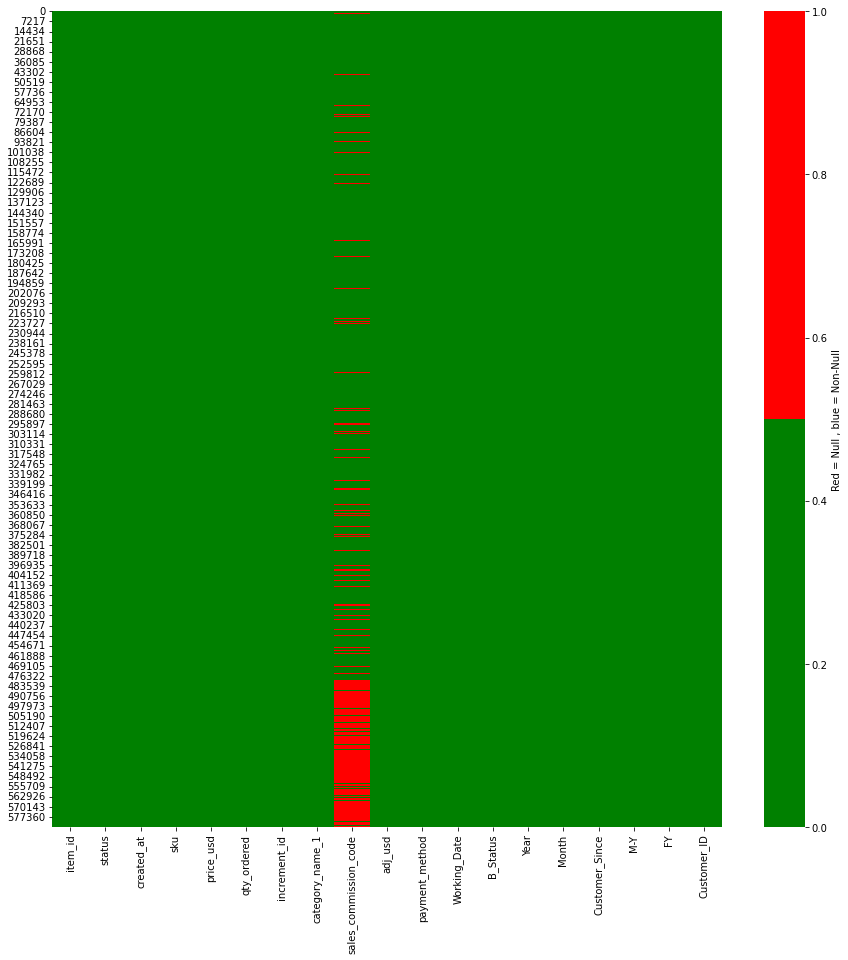

```python
## An overview of the dataframe11
cols = Df1.columns[:]        #
colours = ['green', 'red']      # specify the colours - red is missing. blue is not missing.

plt.subplots(figsize=(15,15))  # magnify the plot size to view the details

sb.heatmap(Df1[cols].isnull(), cmap=sb.color_palette(colours), cbar_kws={'label': 'Red = Null , blue = Non-Null', 'orientation': 'vertical'})
# plotting as heatmap for null values, with colormap following your specified colors, set cbar arguments
plt.xticks(rotation=90)
plt.show()
```

### Note: The category_name_1 and sales_commission_code were required more cleaning, many null data

### But sales_commission_code may not be useful for this analysis.

# Clean up Strategy:

### 1. There are 19 Columns and 585K rows, a big dataset. Many clean up have to do.

### 2. Many columns are repeating or not so useful for Sales Projection/ Sales Improvements.

### 3. There are aslo missing elements, for example: Country, Regions.

### 4. Enhance the values of data, for example: Sales (Value on quantity and unit price only).

### 5. Focus on what we need for analysis, and store in a dataset for analysis.

### 6. The Dataset will be name from Df1 and roll up when changes, so any mistakes, can be roll back to previous dataframe with minimum rework.

```python
## Check Df attributes ##
print(Df1.columns)
print("\n", Df1.shape)
print("\n", Df1.index)
print("\n", Df1.values)
```

```
Index(['item_id', 'status', 'created_at', 'sku', 'price_usd', 'qty_ordered',
       'increment_id', 'category_name_1', 'sales_commission_code', 'adj_usd',
       'payment_method', 'Working_Date', 'B_Status', 'Year', 'Month',
       'Customer_Since', 'M-Y', 'FY', 'Customer_ID'],
      dtype='object')

 (584524, 19)

 RangeIndex(start=0, stop=584524, step=1)

 [[211131 'complete' '7/1/2016' ... 'Jul-16' 'FY17' 1.0]
 [211133 'canceled' '7/1/2016' ... 'Jul-16' 'FY17' 2.0]
 [324257 'canceled' '11/25/2016' ... 'Nov-16' 'FY17' 2.0]
 ...
 [807010 'canceled' '3/27/2018' ... 'Mar-18' 'FY18' nan]
 [808287 'order_refunded' '3/27/2018' ... 'Mar-18' 'FY18' nan]
 [814174 'canceled' '3/28/2018' ... 'Mar-18' 'FY18' nan]]
```

# Adding Country and Regions into this Dataset in 2 steps

## From both internal dataset (Invoicing dataset) and external (Covid) Dataset

## 1. Joining the Invoice Dataset (internal) to include "Country" in the Working dataframe, Df1

## 2. Adding Regions to the dataset (using Country to merge).

### 1. The Invoice Dataset (Df2) - Other column was removed.

```python
## Read the Invoice Dataset (Internal)

Df2 = pd.read_csv("eCommerce_CustomerID_country_invoice18.csv", header=0)

Df2
```

|  | Customer_ID | Country |
| --- | --- | --- |
| 0 | 1.0 | Australia |
| 1 | 2.0 | Australia |
| 2 | 3.0 | Australia |
| 3 | 4.0 | Australia |
| 4 | 5.0 | Australia |
| ... | ... | ... |
| 115322 | 115323.0 | Spain |
| 115323 | 115324.0 | Sweden |
| 115324 | 115325.0 | Switzerland |
| 115325 | 115326.0 | United Arab Emirates |
| 115326 | NaN | United Kingdom |

115327 rows × 2 columns

```python
Df2.info()
```

```
<class 'pandas.core.frame.DataFrame'>
RangeIndex: 115327 entries, 0 to 115326
Data columns (total 2 columns):
 #   Column       Non-Null Count   Dtype
---  ------       --------------   -----
 0   Customer_ID  115326 non-null  float64
 1   Country      115327 non-null  object
dtypes: float64(1), object(1)
memory usage: 1.8+ MB
```

```python
Df1.info()
```

```
<class 'pandas.core.frame.DataFrame'>
RangeIndex: 584524 entries, 0 to 584523
Data columns (total 19 columns):
 #   Column                 Non-Null Count   Dtype
---  ------                 --------------   -----
 0   item_id                584524 non-null  int64
 1   status                 584509 non-null  object
 2   created_at             584524 non-null  object
 3   sku                    584504 non-null  object
 4   price_usd              584524 non-null  float64
 5   qty_ordered            584524 non-null  int64
 6   increment_id           584524 non-null  object
 7   category_name_1        584360 non-null  object
 8   sales_commission_code  447349 non-null  object
 9   adj_usd                584524 non-null  float64
 10  payment_method         584524 non-null  object
 11  Working_Date           584524 non-null  object
 12  B_Status               584524 non-null  object
 13  Year                   584524 non-null  int64
 14  Month                  584524 non-null  int64
 15  Customer_Since         584513 non-null  object
 16  M-Y                    584524 non-null  object
 17  FY                     584524 non-null  object
 18  Customer_ID            584513 non-null  float64
dtypes: float64(3), int64(4), object(12)
memory usage: 84.7+ MB
```

### Joining the eCommerceDataset with the Invoice Dataset (internal Dataset) ==> Df3

```python
Df3 = pd.merge(Df1, Df2, on='Customer_ID')

Df3
```

|  | item_id | status | created_at | sku | price_usd | qty_ordered | increment_id | category_name_1 | sales_commission_code | adj_usd | payment_method | Working_Date | B_Status | Year | Month | Customer_Since | M-Y | FY | Customer_ID | Country |
| --- | --- | --- | --- | --- | --- | --- | --- | --- | --- | --- | --- | --- | --- | --- | --- | --- | --- | --- | --- | --- |
| 0 | 211131 | complete | 7/1/2016 | kreations_YI 06-L | 11.63 | 1 | 100147443 | Women's Fashion | \N | 0.0 | cod | 7/1/2016 | Valid | 2016 | 7 | 2016-7 | Jul-16 | FY17 | 1.0 | Australia |
| 1 | 211133 | canceled | 7/1/2016 | kcc_Buy 2 Frey Air Freshener & Get 1 Kasual Bo... | 1.43 | 1 | 100147444 | Beauty & Grooming | \N | 0.0 | cod | 7/1/2016 | Gross | 2016 | 7 | 2016-7 | Jul-16 | FY17 | 2.0 | Australia |
| 2 | 324257 | canceled | 11/25/2016 | RS_Habshi Halwa Tin | 1.61 | 1 | 100222998 | Soghaat | \N | 0.0 | jazzvoucher | 11/25/2016 | Gross | 2016 | 11 | 2016-7 | Nov-16 | FY17 | 2.0 | Australia |
| 3 | 211134 | canceled | 7/1/2016 | Ego_UP0017-999-MR0 | 14.62 | 1 | 100147445 | Women's Fashion | \N | 0.0 | cod | 7/1/2016 | Gross | 2016 | 7 | 2016-7 | Jul-16 | FY17 | 3.0 | Australia |
| 4 | 473369 | complete | 5/19/2017 | BT_BT-422 | 3.16 | 1 | 100306394 | Men's Fashion | \N | 0.0 | cod | 5/19/2017 | Net | 2017 | 5 | 2016-7 | May-17 | FY17 | 3.0 | Australia |
| ... | ... | ... | ... | ... | ... | ... | ... | ... | ... | ... | ... | ... | ... | ... | ... | ... | ... | ... | ... | ... |
| 584519 | 804621 | canceled | 3/27/2018 | OTHPCB5AB351ED6A8F2 | 29.83 | 2 | 100496269 | Others | NaN | 0.0 | Easypay | 3/27/2018 | Gross | 2018 | 3 | NaN | Mar-18 | FY18 | NaN | United Kingdom |
| 584520 | 805750 | canceled | 3/27/2018 | OTHPCB5AB351ECC7118 | 2.98 | 2 | 100497359 | Others | NaN | 0.0 | Easypay | 3/27/2018 | Gross | 2018 | 3 | NaN | Mar-18 | FY18 | NaN | United Kingdom |
| 584521 | 807010 | canceled | 3/27/2018 | OTHPCB5AB351EEC46EC | 2.98 | 4 | 100498582 | Others | NaN | 0.0 | Easypay | 3/27/2018 | Gross | 2018 | 3 | NaN | Mar-18 | FY18 | NaN | United Kingdom |
| 584522 | 808287 | order_refunded | 3/27/2018 | MEFKAR5A7C138CE9EBD-L | 6.21 | 1 | 100499821 | Men's Fashion | NaN | 0.0 | cod | 3/27/2018 | Valid | 2018 | 3 | NaN | Mar-18 | FY18 | NaN | United Kingdom |
| 584523 | 814174 | canceled | 3/28/2018 | OTHPCB5ABB207673754 | 11.93 | 5 | 100505460 | Others | NaN | 0.0 | Easypay | 3/28/2018 | Gross | 2018 | 3 | NaN | Mar-18 | FY18 | NaN | United Kingdom |

584524 rows × 20 columns

### Removing the Nan at Column (Customer_ID) after merging the datasets

```python
# under certain label
Df4 = Df3.dropna(subset=['Customer_ID'])

# Resetting the indices using df.reset_index()
Df4 = Df4.reset_index(drop=True)

Df4
```

|  | item_id | status | created_at | sku | price_usd | qty_ordered | increment_id | category_name_1 | sales_commission_code | adj_usd | payment_method | Working_Date | B_Status | Year | Month | Customer_Since | M-Y | FY | Customer_ID | Country |
| --- | --- | --- | --- | --- | --- | --- | --- | --- | --- | --- | --- | --- | --- | --- | --- | --- | --- | --- | --- | --- |
| 0 | 211131 | complete | 7/1/2016 | kreations_YI 06-L | 11.63 | 1 | 100147443 | Women's Fashion | \N | 0.0 | cod | 7/1/2016 | Valid | 2016 | 7 | 2016-7 | Jul-16 | FY17 | 1.0 | Australia |
| 1 | 211133 | canceled | 7/1/2016 | kcc_Buy 2 Frey Air Freshener & Get 1 Kasual Bo... | 1.43 | 1 | 100147444 | Beauty & Grooming | \N | 0.0 | cod | 7/1/2016 | Gross | 2016 | 7 | 2016-7 | Jul-16 | FY17 | 2.0 | Australia |
| 2 | 324257 | canceled | 11/25/2016 | RS_Habshi Halwa Tin | 1.61 | 1 | 100222998 | Soghaat | \N | 0.0 | jazzvoucher | 11/25/2016 | Gross | 2016 | 11 | 2016-7 | Nov-16 | FY17 | 2.0 | Australia |
| 3 | 211134 | canceled | 7/1/2016 | Ego_UP0017-999-MR0 | 14.62 | 1 | 100147445 | Women's Fashion | \N | 0.0 | cod | 7/1/2016 | Gross | 2016 | 7 | 2016-7 | Jul-16 | FY17 | 3.0 | Australia |
| 4 | 473369 | complete | 5/19/2017 | BT_BT-422 | 3.16 | 1 | 100306394 | Men's Fashion | \N | 0.0 | cod | 5/19/2017 | Net | 2017 | 5 | 2016-7 | May-17 | FY17 | 3.0 | Australia |
| ... | ... | ... | ... | ... | ... | ... | ... | ... | ... | ... | ... | ... | ... | ... | ... | ... | ... | ... | ... | ... |
| 584508 | 905179 | paid | 8/28/2018 | APPCHA5AF14939B8F8A | 263.72 | 1 | 100562365 | Appliances | NaN | 0.0 | Easypay | 8/28/2018 | Valid | 2018 | 8 | 2018-8 | Aug-18 | FY19 | 115323.0 | Spain |
| 584509 | 905191 | cod | 8/28/2018 | MEFCOT5A8D1E973B886 | 2.38 | 1 | 100562376 | Men's Fashion | NaN | 0.0 | cod | 8/28/2018 | Valid | 2018 | 8 | 2018-8 | Aug-18 | FY19 | 115324.0 | Sweden |
| 584510 | 905200 | cod | 8/28/2018 | WOFVAL59D5EA84167F9-M | 2.39 | 1 | 100562383 | Women's Fashion | NaN | 0.0 | cod | 8/28/2018 | Valid | 2018 | 8 | 2018-8 | Aug-18 | FY19 | 115325.0 | Switzerland |
| 584511 | 905202 | cod | 8/28/2018 | WOFNIG5B4D7EB0E9FDD-L | 2.98 | 1 | 100562384 | Women's Fashion | NaN | 0.0 | cod | 8/28/2018 | Valid | 2018 | 8 | 2018-8 | Aug-18 | FY19 | 115325.0 | Switzerland |
| 584512 | 905205 | processing | 8/28/2018 | MATHUA5AF70A7D1E50A | 212.40 | 1 | 100562386 | Mobiles & Tablets | NaN | 0.0 | bankalfalah | 8/28/2018 | Gross | 2018 | 8 | 2018-8 | Aug-18 | FY19 | 115326.0 | United Arab Emirates |

584513 rows × 20 columns

```python
Df3 = Df4  ## Update the Dateset

Df3.info()
```

```
<class 'pandas.core.frame.DataFrame'>
RangeIndex: 584513 entries, 0 to 584512
Data columns (total 20 columns):
 #   Column                 Non-Null Count   Dtype
---  ------                 --------------   -----
 0   item_id                584513 non-null  int64
 1   status                 584498 non-null  object
 2   created_at             584513 non-null  object
 3   sku                    584493 non-null  object
 4   price_usd              584513 non-null  float64
 5   qty_ordered            584513 non-null  int64
 6   increment_id           584513 non-null  object
 7   category_name_1        584349 non-null  object
 8   sales_commission_code  447349 non-null  object
 9   adj_usd                584513 non-null  float64
 10  payment_method         584513 non-null  object
 11  Working_Date           584513 non-null  object
 12  B_Status               584513 non-null  object
 13  Year                   584513 non-null  int64
 14  Month                  584513 non-null  int64
 15  Customer_Since         584513 non-null  object
 16  M-Y                    584513 non-null  object
 17  FY                     584513 non-null  object
 18  Customer_ID            584513 non-null  float64
 19  Country                584513 non-null  object
dtypes: float64(3), int64(4), object(13)
memory usage: 89.2+ MB
```

## Finding the Number of Unique Records in the Dataset (Find the Unique ID)

### Number of unique Country: 37 in Df3

```python
country_count = []

cnt = 0

for i in range(0, len(Df3['Country'])):

    if Df3['Country'][i] not in country_count:

        country_count.append(Df3['Country'][i])

        cnt += 1

print("No of unique Country :", cnt)

print("The unique Countries are :", country_count)
```

```
No of unique Country : 37
The unique Countries are : ['Australia', 'Denmark', 'EIRE', 'European Community', 'Finland', 'Lebanon', 'Lithuania', 'Malta', 'Netherlands', 'Switzerland', 'United Arab Emirates', 'United Kingdom', 'Unspecified', 'USA', 'Saudi Arabia', 'Singapore', 'Brazil', 'Canada', 'Channel Islands', 'Cyprus', 'C…
```

## Finding Min, max, mode, and range in a column

### Quantity:

```python
# get the maximum value of the column 'Quantity'

max_quantity = Df3['qty_ordered'].max()
min_quantity = Df3['qty_ordered'].min()
mode_quantity = Df3['qty_ordered'].mode()

print("The largest quantity ordered is:", max_quantity)
print("The smallest quantity ordered is:", min_quantity)
print("The most frequent ordered quantity is:", mode_quantity)
```

```
The largest quantity ordered is: 1000
The smallest quantity ordered is: 1
The most frequent ordered quantity is: 0    1
Name: qty_ordered, dtype: int64
```

### Unit Price:

```python
# get the maximum value of the column 'UnitPrice'

max_unitprice = Df3['price_usd'].max()
min_unitprice = Df3['price_usd'].min()
mode_unitprice = Df3['price_usd'].mode()

print("The highest unit price is:", max_unitprice)
print("The lowest unit price is:", min_unitprice)
print("The most frequent used unit price is:", mode_unitprice)
```

```
The highest unit price is: 6041.92
The lowest unit price is: 0.0
The most frequent used unit price is: 0    2.98
Name: price_usd, dtype: float64
```

### The zero unit price is most likely a typo. In this case, the decision is to delete the records (rows)

```python
Df3 =Df3.query("price_usd > 0")   # Using Dataframe for making the changes.

Df3 = Df3.reset_index(drop=True)
```

```python
# get the maximum value of the column 'UnitPrice'

max_unitprice = Df3['price_usd'].max()
min_unitprice = Df3['price_usd'].min()
mode_unitprice = Df3['price_usd'].mode()

print("The highest unit price is:", max_unitprice)
print("The lowest unit price is:", min_unitprice)
print("The most frequent used unit price is:", mode_unitprice)
```

```
The highest unit price is: 6041.92
The lowest unit price is: 0.01
The most frequent used unit price is: 0    2.98
Name: price_usd, dtype: float64
```

### The 0.0 price was removed. done.

## Adding Regions in the dataset from using Country/ ISO code from Covid Dataset:

### 1. There are 37 countries in this dataset. Suggest to creat a new Subgroup.

### 2. This could be grouped by Asia, Europe etc. (Adding ISO Code and Regions column from Covid Dataset). This changes the dataframe structure.

## Restructure DataFrame by adding in new ISO code and Regions (COVID Dataset) DfC:

```python
## Read the Country Code Dataset

DfC = pd.read_csv("Country Code.csv", header=0)

DfC
```

|  | location | iso_code | continent |
| --- | --- | --- | --- |
| 0 | Afghanistan | AFG | Asia |
| 1 | Albania | ALB | Europe |
| 2 | Algeria | DZA | Africa |
| 3 | Andorra | AND | Europe |
| 4 | Angola | AGO | Africa |
| ... | ... | ... | ... |
| 213 | Vietnam | VNM | Asia |
| 214 | Wallis and Futuna | WLF | Oceania |
| 215 | Yemen | YEM | Asia |
| 216 | Zambia | ZMB | Africa |
| 217 | Zimbabwe | ZWE | Africa |

218 rows × 3 columns

### Rename the columns for joining the 2 dataframes.

```python
DfC.columns = ['Country', 'ISO_code', 'Regions']

DfC
```

|  | Country | ISO_code | Regions |
| --- | --- | --- | --- |
| 0 | Afghanistan | AFG | Asia |
| 1 | Albania | ALB | Europe |
| 2 | Algeria | DZA | Africa |
| 3 | Andorra | AND | Europe |
| 4 | Angola | AGO | Africa |
| ... | ... | ... | ... |
| 213 | Vietnam | VNM | Asia |
| 214 | Wallis and Futuna | WLF | Oceania |
| 215 | Yemen | YEM | Asia |
| 216 | Zambia | ZMB | Africa |
| 217 | Zimbabwe | ZWE | Africa |

218 rows × 3 columns

### Creat a List for the 218 countries

```python
isocountry_list = []

cnt = 0

for i in range(0, len(DfC['Country'])):

    if DfC['Country'][i] not in isocountry_list:

        isocountry_list.append(DfC['Country'][i])

        cnt += 1

print("No of unique Country:", cnt)

print("The unique Countries are:", isocountry_list)
```

```
No of unique Country: 218
The unique Countries are: ['Afghanistan', 'Albania', 'Algeria', 'Andorra', 'Angola', 'Anguilla', 'Antigua and Barbuda', 'Argentina', 'Armenia', 'Aruba', 'Australia', 'Austria', 'Azerbaijan', 'Bahamas', 'Bahrain', 'Bangladesh', 'Barbados', 'Belarus', 'Belgium', 'Belize', 'Benin', 'Bermuda', 'Bhutan',…
```

### Joining the 2 DataFrame (DataFrame 1 (Df1) and DataFrameC (DfC) using "Country"

```python
Df4 = pd.merge(Df3, DfC, on='Country')

Df4
```

|  | item_id | status | created_at | sku | price_usd | qty_ordered | increment_id | category_name_1 | sales_commission_code | adj_usd | ... | B_Status | Year | Month | Customer_Since | M-Y | FY | Customer_ID | Country | ISO_code | Regions |
| --- | --- | --- | --- | --- | --- | --- | --- | --- | --- | --- | --- | --- | --- | --- | --- | --- | --- | --- | --- | --- | --- |
| 0 | 211131 | complete | 7/1/2016 | kreations_YI 06-L | 11.63 | 1 | 100147443 | Women's Fashion | \N | 0.0 | ... | Valid | 2016 | 7 | 2016-7 | Jul-16 | FY17 | 1.0 | Australia | AUS | Oceania |
| 1 | 211133 | canceled | 7/1/2016 | kcc_Buy 2 Frey Air Freshener & Get 1 Kasual Bo... | 1.43 | 1 | 100147444 | Beauty & Grooming | \N | 0.0 | ... | Gross | 2016 | 7 | 2016-7 | Jul-16 | FY17 | 2.0 | Australia | AUS | Oceania |
| 2 | 324257 | canceled | 11/25/2016 | RS_Habshi Halwa Tin | 1.61 | 1 | 100222998 | Soghaat | \N | 0.0 | ... | Gross | 2016 | 11 | 2016-7 | Nov-16 | FY17 | 2.0 | Australia | AUS | Oceania |
| 3 | 211134 | canceled | 7/1/2016 | Ego_UP0017-999-MR0 | 14.62 | 1 | 100147445 | Women's Fashion | \N | 0.0 | ... | Gross | 2016 | 7 | 2016-7 | Jul-16 | FY17 | 3.0 | Australia | AUS | Oceania |
| 4 | 473369 | complete | 5/19/2017 | BT_BT-422 | 3.16 | 1 | 100306394 | Men's Fashion | \N | 0.0 | ... | Net | 2017 | 5 | 2016-7 | May-17 | FY17 | 3.0 | Australia | AUS | Oceania |
| ... | ... | ... | ... | ... | ... | ... | ... | ... | ... | ... | ... | ... | ... | ... | ... | ... | ... | ... | ... | ... | ... |
| 466587 | 904365 | received | 8/25/2018 | HASQAR5A744999A7B52 | 0.79 | 1 | 100561921 | Health & Sports | NaN | 0.0 | ... | Valid | 2018 | 8 | 2018-8 | Aug-18 | FY19 | 115185.0 | Belgium | BEL | Europe |
| 466588 | 904607 | canceled | 8/26/2018 | BAGTRA5A0C12CBAC37B | 5.37 | 1 | 100562045 | Beauty & Grooming | NaN | 0.0 | ... | Gross | 2018 | 8 | 2018-8 | Aug-18 | FY19 | 115222.0 | Belgium | BEL | Europe |
| 466589 | 904608 | canceled | 8/26/2018 | BAGROM5AAF9D112383E | 5.96 | 1 | 100562045 | Beauty & Grooming | NaN | 0.0 | ... | Gross | 2018 | 8 | 2018-8 | Aug-18 | FY19 | 115222.0 | Belgium | BEL | Europe |
| 466590 | 904796 | canceled | 8/27/2018 | MATNOK5B2B7E715DF70 | 29.83 | 1 | 100562160 | Mobiles & Tablets | NaN | 0.0 | ... | Gross | 2018 | 8 | 2018-8 | Aug-18 | FY19 | 115259.0 | Belgium | BEL | Europe |
| 466591 | 904987 | holded | 8/27/2018 | ENTCHA5B6A8FEA10D06 | 160.98 | 1 | 100562269 | Entertainment | NaN | 0.0 | ... | Gross | 2018 | 8 | 2018-8 | Aug-18 | FY19 | 115296.0 | Belgium | BEL | Europe |

466592 rows × 22 columns

### Note: 2 New Columns were included in the DataFrame2, Iso and Regions It looks good.

## Double check if the Country Counts remains the same:

### The original 37 countries in Df3 (Before merged):

```python
country_list = []

cnt = 0

for i in range(0, len(Df3['Country'])):

    if Df3['Country'][i] not in country_list:

        country_list.append(Df3['Country'][i])

        cnt += 1


print("No of unique Country before merged:", cnt)
print()
print("The unique Countries are :", country_list)
```

```
No of unique Country before merged: 37

The unique Countries are : ['Australia', 'Denmark', 'EIRE', 'European Community', 'Finland', 'Lebanon', 'Lithuania', 'Malta', 'Netherlands', 'Switzerland', 'United Arab Emirates', 'United Kingdom', 'Unspecified', 'USA', 'Saudi Arabia', 'Singapore', 'Brazil', 'Canada', 'Channel Islands', 'Cyprus', 'C…
```

### The countries in the merged dataset (Df4):

```python
mergedcountry_count = []

cnt = 0

for i in range(0, len(Df4['Country'])):

    if Df4['Country'][i] not in mergedcountry_count:

        mergedcountry_count.append(Df4['Country'][i])

        cnt += 1

print("No of unique Country after merged:", cnt)
print()
print("The merged Countries list is:", mergedcountry_count)
```

```
No of unique Country after merged: 30

The merged Countries list is: ['Australia', 'Denmark', 'Finland', 'Lebanon', 'Lithuania', 'Malta', 'Netherlands', 'Switzerland', 'United Arab Emirates', 'United Kingdom', 'Saudi Arabia', 'Singapore', 'Brazil', 'Canada', 'Cyprus', 'France', 'Germany', 'Greece', 'Iceland', 'Israel', 'Spain', 'Italy', …
```

### Problem: There is 7 Countries short in the merged (Df4)!!

```python
if_contains = country_list

have_list = []

words = isocountry_list

for word in words:
    for el in if_contains:
        if el in word:
            have_list.append(word)

print("The no of country in the merged list is:", len(have_list))
print()
print("The Countries in the original dateset has", len(country_list)-len(have_list), "More countries")
print()
print("Only these countries are in the merged Df4:")
print(have_list)
```

```
The no of country in the merged list is: 30

The Countries in the original dateset has 7 More countries

Only these countries are in the merged Df4:
['Australia', 'Austria', 'Bahrain', 'Belgium', 'Brazil', 'Canada', 'Cyprus', 'Denmark', 'Finland', 'France', 'Germany', 'Greece', 'Iceland', 'Israel', 'Italy', 'Japan', 'Lebanon', 'Lithuania', 'Malta', 'Netherlands', 'Norway', 'Poland', 'Portugal', 'Saudi Arabia', 'Singapore', 'Spain', 'Sweden', 'Sw…
```

```python
set1 = set(have_list)
set2 = set(country_list)

missing_country = set1.symmetric_difference(set2)

print("The no of missing country is:", len(missing_country))
print()
print("The missing countries are:", missing_country)
```

```
The no of missing country is: 7

The missing countries are: {'EIRE', 'Unspecified', 'Czech Republic', 'European Community', 'Channel Islands', 'RSA', 'USA'}
```

### Double check if the 7 missing countries are in the ISO Countries List (DfC):

```python
if_contains = missing_country

check_list = []

words = isocountry_list

for word in words:
    for el in if_contains:
        if el in word:
            check_list.append(word)

print("The no of missing country in the isocountry list is:", len(check_list))
#print()
#print("The Countries in the dateset has", len(country_list)-len(have_list), "More countries")
#print()
#print("Only these countries are in the merged Df4:")
print(check_list)
```

```
The no of missing country in the isocountry list is: 0
[]
```

### These 7 countries were not in the ISO Dataset!!

### Manually review these 7 missing countries:

```python
print()
print("The missing countries are:", missing_country)
```

```
The missing countries are: {'EIRE', 'Unspecified', 'Czech Republic', 'European Community', 'Channel Islands', 'RSA', 'USA'}
```

## Problem-solving after checked on these 7 countries:

### Below is to amend the DataFrame to avoid deleting the data:

### 1. Channel Islands is not a Country, So to add to the ISO List (to group it under Europe)

### 2. The USA should be United States (in ISO dataset). - To amend DataFrame

### 3. European Community is not a country - to change it to unspecified

### 4. Czech Republic is now Czechia (in ISO dataset) - amend the dataFrame

### 5. EIRE is Ireland (in ISO dataset) - To amend the DataFrame

### 6. Add Unspecified into the ISO Country List before merging

### 7. No RSA as a country, it could be some data entry errors, to change it to unspecified.

## Below is to amend the ISO Country to avoid deleting the data:

### 1. Channel Islands is not a Country, So to add to the ISO List (to group it under Europe)

### 2. Add Unspecified into the ISO Country List before merging.

## Correcting the countries issues (Df5):

```python
Df5 = Df3

Df5["Country"].replace({"USA": "United States", "EIRE": "Ireland", "RSA": "Unspecified", "Czech Republic": "Czechia", "European Community": "Unspecified"}, inplace=True)

Df5
```

|  | item_id | status | created_at | sku | price_usd | qty_ordered | increment_id | category_name_1 | sales_commission_code | adj_usd | payment_method | Working_Date | B_Status | Year | Month | Customer_Since | M-Y | FY | Customer_ID | Country |
| --- | --- | --- | --- | --- | --- | --- | --- | --- | --- | --- | --- | --- | --- | --- | --- | --- | --- | --- | --- | --- |
| 0 | 211131 | complete | 7/1/2016 | kreations_YI 06-L | 11.63 | 1 | 100147443 | Women's Fashion | \N | 0.0 | cod | 7/1/2016 | Valid | 2016 | 7 | 2016-7 | Jul-16 | FY17 | 1.0 | Australia |
| 1 | 211133 | canceled | 7/1/2016 | kcc_Buy 2 Frey Air Freshener & Get 1 Kasual Bo... | 1.43 | 1 | 100147444 | Beauty & Grooming | \N | 0.0 | cod | 7/1/2016 | Gross | 2016 | 7 | 2016-7 | Jul-16 | FY17 | 2.0 | Australia |
| 2 | 324257 | canceled | 11/25/2016 | RS_Habshi Halwa Tin | 1.61 | 1 | 100222998 | Soghaat | \N | 0.0 | jazzvoucher | 11/25/2016 | Gross | 2016 | 11 | 2016-7 | Nov-16 | FY17 | 2.0 | Australia |
| 3 | 211134 | canceled | 7/1/2016 | Ego_UP0017-999-MR0 | 14.62 | 1 | 100147445 | Women's Fashion | \N | 0.0 | cod | 7/1/2016 | Gross | 2016 | 7 | 2016-7 | Jul-16 | FY17 | 3.0 | Australia |
| 4 | 473369 | complete | 5/19/2017 | BT_BT-422 | 3.16 | 1 | 100306394 | Men's Fashion | \N | 0.0 | cod | 5/19/2017 | Net | 2017 | 5 | 2016-7 | May-17 | FY17 | 3.0 | Australia |
| ... | ... | ... | ... | ... | ... | ... | ... | ... | ... | ... | ... | ... | ... | ... | ... | ... | ... | ... | ... | ... |
| 582227 | 905179 | paid | 8/28/2018 | APPCHA5AF14939B8F8A | 263.72 | 1 | 100562365 | Appliances | NaN | 0.0 | Easypay | 8/28/2018 | Valid | 2018 | 8 | 2018-8 | Aug-18 | FY19 | 115323.0 | Spain |
| 582228 | 905191 | cod | 8/28/2018 | MEFCOT5A8D1E973B886 | 2.38 | 1 | 100562376 | Men's Fashion | NaN | 0.0 | cod | 8/28/2018 | Valid | 2018 | 8 | 2018-8 | Aug-18 | FY19 | 115324.0 | Sweden |
| 582229 | 905200 | cod | 8/28/2018 | WOFVAL59D5EA84167F9-M | 2.39 | 1 | 100562383 | Women's Fashion | NaN | 0.0 | cod | 8/28/2018 | Valid | 2018 | 8 | 2018-8 | Aug-18 | FY19 | 115325.0 | Switzerland |
| 582230 | 905202 | cod | 8/28/2018 | WOFNIG5B4D7EB0E9FDD-L | 2.98 | 1 | 100562384 | Women's Fashion | NaN | 0.0 | cod | 8/28/2018 | Valid | 2018 | 8 | 2018-8 | Aug-18 | FY19 | 115325.0 | Switzerland |
| 582231 | 905205 | processing | 8/28/2018 | MATHUA5AF70A7D1E50A | 212.40 | 1 | 100562386 | Mobiles & Tablets | NaN | 0.0 | bankalfalah | 8/28/2018 | Gross | 2018 | 8 | 2018-8 | Aug-18 | FY19 | 115326.0 | United Arab Emirates |

582232 rows × 20 columns

```python
newcountry_list = []

cnt = 0

for i in range(0, len(Df5['Country'])):

    if Df5['Country'][i] not in newcountry_list:

        newcountry_list.append(Df5['Country'][i])

        cnt += 1

print("No of new unique Country in the merged Df6:", cnt)
print()
print("The unique new Countries are :", newcountry_list)
```

```
No of new unique Country in the merged Df6: 35

The unique new Countries are : ['Australia', 'Denmark', 'Ireland', 'Unspecified', 'Finland', 'Lebanon', 'Lithuania', 'Malta', 'Netherlands', 'Switzerland', 'United Arab Emirates', 'United Kingdom', 'United States', 'Saudi Arabia', 'Singapore', 'Brazil', 'Canada', 'Channel Islands', 'Cyprus', 'Czechi…
```

### Adding 2 rows in the ISO Code (DfC1)

```python
DfC1 = DfC

# DfC1 = pd.read_csv("Country Code.csv", header=0)
# DfC1.columns = ['Country', 'ISO_code', 'Regions']

DfC1.loc[len(DfC1.index)] = ['Channel Islands', 'Channel Islands', 'Europe']
DfC1.loc[len(DfC1.index)] = ['Unspecified', 'Unspecified', 'Unspecified']

DfC1
```

|  | Country | ISO_code | Regions |
| --- | --- | --- | --- |
| 0 | Afghanistan | AFG | Asia |
| 1 | Albania | ALB | Europe |
| 2 | Algeria | DZA | Africa |
| 3 | Andorra | AND | Europe |
| 4 | Angola | AGO | Africa |
| ... | ... | ... | ... |
| 215 | Yemen | YEM | Asia |
| 216 | Zambia | ZMB | Africa |
| 217 | Zimbabwe | ZWE | Africa |
| 218 | Channel Islands | Channel Islands | Europe |
| 219 | Unspecified | Unspecified | Unspecified |

220 rows × 3 columns

### 2nd joining the 2 DataFrame (Df5) and DataFrameC (DfC1) using "Country" ==> Df6

### Df6, the most updated Dataframe including all corrections so far.

```python
Df6 = pd.merge(Df5, DfC1, on='Country')

Df6  ## Most updated Dataframe including all corrections so far.
```

|  | item_id | status | created_at | sku | price_usd | qty_ordered | increment_id | category_name_1 | sales_commission_code | adj_usd | ... | B_Status | Year | Month | Customer_Since | M-Y | FY | Customer_ID | Country | ISO_code | Regions |
| --- | --- | --- | --- | --- | --- | --- | --- | --- | --- | --- | --- | --- | --- | --- | --- | --- | --- | --- | --- | --- | --- |
| 0 | 211131 | complete | 7/1/2016 | kreations_YI 06-L | 11.63 | 1 | 100147443 | Women's Fashion | \N | 0.0 | ... | Valid | 2016 | 7 | 2016-7 | Jul-16 | FY17 | 1.0 | Australia | AUS | Oceania |
| 1 | 211133 | canceled | 7/1/2016 | kcc_Buy 2 Frey Air Freshener & Get 1 Kasual Bo... | 1.43 | 1 | 100147444 | Beauty & Grooming | \N | 0.0 | ... | Gross | 2016 | 7 | 2016-7 | Jul-16 | FY17 | 2.0 | Australia | AUS | Oceania |
| 2 | 324257 | canceled | 11/25/2016 | RS_Habshi Halwa Tin | 1.61 | 1 | 100222998 | Soghaat | \N | 0.0 | ... | Gross | 2016 | 11 | 2016-7 | Nov-16 | FY17 | 2.0 | Australia | AUS | Oceania |
| 3 | 211134 | canceled | 7/1/2016 | Ego_UP0017-999-MR0 | 14.62 | 1 | 100147445 | Women's Fashion | \N | 0.0 | ... | Gross | 2016 | 7 | 2016-7 | Jul-16 | FY17 | 3.0 | Australia | AUS | Oceania |
| 4 | 473369 | complete | 5/19/2017 | BT_BT-422 | 3.16 | 1 | 100306394 | Men's Fashion | \N | 0.0 | ... | Net | 2017 | 5 | 2016-7 | May-17 | FY17 | 3.0 | Australia | AUS | Oceania |
| ... | ... | ... | ... | ... | ... | ... | ... | ... | ... | ... | ... | ... | ... | ... | ... | ... | ... | ... | ... | ... | ... |
| 582227 | 904365 | received | 8/25/2018 | HASQAR5A744999A7B52 | 0.79 | 1 | 100561921 | Health & Sports | NaN | 0.0 | ... | Valid | 2018 | 8 | 2018-8 | Aug-18 | FY19 | 115185.0 | Belgium | BEL | Europe |
| 582228 | 904607 | canceled | 8/26/2018 | BAGTRA5A0C12CBAC37B | 5.37 | 1 | 100562045 | Beauty & Grooming | NaN | 0.0 | ... | Gross | 2018 | 8 | 2018-8 | Aug-18 | FY19 | 115222.0 | Belgium | BEL | Europe |
| 582229 | 904608 | canceled | 8/26/2018 | BAGROM5AAF9D112383E | 5.96 | 1 | 100562045 | Beauty & Grooming | NaN | 0.0 | ... | Gross | 2018 | 8 | 2018-8 | Aug-18 | FY19 | 115222.0 | Belgium | BEL | Europe |
| 582230 | 904796 | canceled | 8/27/2018 | MATNOK5B2B7E715DF70 | 29.83 | 1 | 100562160 | Mobiles & Tablets | NaN | 0.0 | ... | Gross | 2018 | 8 | 2018-8 | Aug-18 | FY19 | 115259.0 | Belgium | BEL | Europe |
| 582231 | 904987 | holded | 8/27/2018 | ENTCHA5B6A8FEA10D06 | 160.98 | 1 | 100562269 | Entertainment | NaN | 0.0 | ... | Gross | 2018 | 8 | 2018-8 | Aug-18 | FY19 | 115296.0 | Belgium | BEL | Europe |

582232 rows × 22 columns

### Review Countries in the new merging....

### No of new unique Country in the merged Df6: 35 - and this is correct!

```python
newcountry_list = []

cnt = 0

for i in range(0, len(Df6['Country'])):

    if Df6['Country'][i] not in newcountry_list:

        newcountry_list.append(Df6['Country'][i])

        cnt += 1

print("No of new unique Country in the merged Df6:", cnt)
print()
print("The unique new Countries are :", newcountry_list)
```

```
No of new unique Country in the merged Df6: 35

The unique new Countries are : ['Australia', 'Denmark', 'Ireland', 'Unspecified', 'Finland', 'Lebanon', 'Lithuania', 'Malta', 'Netherlands', 'Switzerland', 'United Arab Emirates', 'United Kingdom', 'United States', 'Saudi Arabia', 'Singapore', 'Brazil', 'Canada', 'Channel Islands', 'Cyprus', 'Czechi…
```

### The new country list is now 35 and is correct (original 37 ==> Now 35).

### 2 countries ("RSA" and "European Community") were eliminated, their data are now under "Unspecified".

## List of the New Regions:

```python
regions_count = []

cnt = 0

for i in range(0, len(Df6['Regions'])):

    if Df6['Regions'][i] not in regions_count:

        regions_count.append(Df6['Regions'][i])

        cnt += 1

print("No of unique Regions :", cnt)

print("The unique Regions are :", regions_count)
```

```
No of unique Regions : 6
The unique Regions are : ['Oceania', 'Europe', 'Unspecified', 'Asia', 'North America', 'South America']
```

## Summary of adding Countries and Regions:

### The including of Countries were from the internal Invoice Dataset set from Accounting Dept.

### The including of Regions were from external Covid Dataset, some cleaning and modifications were required.

### 1. The New Df6 is now have 35 countries, after eliminated RSA and European Community were droped from the Country and data were included in the Unspecified.

### 2. The New Df6 is now have a Regions grouping (6 Regions) for better Data Analysis and projection and management actions.

### Saving Df6 into .csv file. (Naming file as "eCommerceDataset1_Group1_r01.csv")

```python
Df6.to_csv('eCommerceDataset1_Group1_r01.csv', index=False)

print("Dataframe 6:")
Df6
```

```
Dataframe 6:
```

|  | item_id | status | created_at | sku | price_usd | qty_ordered | increment_id | category_name_1 | sales_commission_code | adj_usd | ... | B_Status | Year | Month | Customer_Since | M-Y | FY | Customer_ID | Country | ISO_code | Regions |
| --- | --- | --- | --- | --- | --- | --- | --- | --- | --- | --- | --- | --- | --- | --- | --- | --- | --- | --- | --- | --- | --- |
| 0 | 211131 | complete | 7/1/2016 | kreations_YI 06-L | 11.63 | 1 | 100147443 | Women's Fashion | \N | 0.0 | ... | Valid | 2016 | 7 | 2016-7 | Jul-16 | FY17 | 1.0 | Australia | AUS | Oceania |
| 1 | 211133 | canceled | 7/1/2016 | kcc_Buy 2 Frey Air Freshener & Get 1 Kasual Bo... | 1.43 | 1 | 100147444 | Beauty & Grooming | \N | 0.0 | ... | Gross | 2016 | 7 | 2016-7 | Jul-16 | FY17 | 2.0 | Australia | AUS | Oceania |
| 2 | 324257 | canceled | 11/25/2016 | RS_Habshi Halwa Tin | 1.61 | 1 | 100222998 | Soghaat | \N | 0.0 | ... | Gross | 2016 | 11 | 2016-7 | Nov-16 | FY17 | 2.0 | Australia | AUS | Oceania |
| 3 | 211134 | canceled | 7/1/2016 | Ego_UP0017-999-MR0 | 14.62 | 1 | 100147445 | Women's Fashion | \N | 0.0 | ... | Gross | 2016 | 7 | 2016-7 | Jul-16 | FY17 | 3.0 | Australia | AUS | Oceania |
| 4 | 473369 | complete | 5/19/2017 | BT_BT-422 | 3.16 | 1 | 100306394 | Men's Fashion | \N | 0.0 | ... | Net | 2017 | 5 | 2016-7 | May-17 | FY17 | 3.0 | Australia | AUS | Oceania |
| ... | ... | ... | ... | ... | ... | ... | ... | ... | ... | ... | ... | ... | ... | ... | ... | ... | ... | ... | ... | ... | ... |
| 582227 | 904365 | received | 8/25/2018 | HASQAR5A744999A7B52 | 0.79 | 1 | 100561921 | Health & Sports | NaN | 0.0 | ... | Valid | 2018 | 8 | 2018-8 | Aug-18 | FY19 | 115185.0 | Belgium | BEL | Europe |
| 582228 | 904607 | canceled | 8/26/2018 | BAGTRA5A0C12CBAC37B | 5.37 | 1 | 100562045 | Beauty & Grooming | NaN | 0.0 | ... | Gross | 2018 | 8 | 2018-8 | Aug-18 | FY19 | 115222.0 | Belgium | BEL | Europe |
| 582229 | 904608 | canceled | 8/26/2018 | BAGROM5AAF9D112383E | 5.96 | 1 | 100562045 | Beauty & Grooming | NaN | 0.0 | ... | Gross | 2018 | 8 | 2018-8 | Aug-18 | FY19 | 115222.0 | Belgium | BEL | Europe |
| 582230 | 904796 | canceled | 8/27/2018 | MATNOK5B2B7E715DF70 | 29.83 | 1 | 100562160 | Mobiles & Tablets | NaN | 0.0 | ... | Gross | 2018 | 8 | 2018-8 | Aug-18 | FY19 | 115259.0 | Belgium | BEL | Europe |
| 582231 | 904987 | holded | 8/27/2018 | ENTCHA5B6A8FEA10D06 | 160.98 | 1 | 100562269 | Entertainment | NaN | 0.0 | ... | Gross | 2018 | 8 | 2018-8 | Aug-18 | FY19 | 115296.0 | Belgium | BEL | Europe |

582232 rows × 22 columns

```python
Df6 = pd.read_csv('eCommerceDataset1_Group1_r01.csv')

print("Df6 = Dataframe 6")
Df6
```

```
Df6 = Dataframe 6
```

|  | item_id | status | created_at | sku | price_usd | qty_ordered | increment_id | category_name_1 | sales_commission_code | adj_usd | ... | B_Status | Year | Month | Customer_Since | M-Y | FY | Customer_ID | Country | ISO_code | Regions |
| --- | --- | --- | --- | --- | --- | --- | --- | --- | --- | --- | --- | --- | --- | --- | --- | --- | --- | --- | --- | --- | --- |
| 0 | 211131 | complete | 7/1/2016 | kreations_YI 06-L | 11.63 | 1 | 100147443 | Women's Fashion | \N | 0.0 | ... | Valid | 2016 | 7 | 2016-7 | Jul-16 | FY17 | 1.0 | Australia | AUS | Oceania |
| 1 | 211133 | canceled | 7/1/2016 | kcc_Buy 2 Frey Air Freshener & Get 1 Kasual Bo... | 1.43 | 1 | 100147444 | Beauty & Grooming | \N | 0.0 | ... | Gross | 2016 | 7 | 2016-7 | Jul-16 | FY17 | 2.0 | Australia | AUS | Oceania |
| 2 | 324257 | canceled | 11/25/2016 | RS_Habshi Halwa Tin | 1.61 | 1 | 100222998 | Soghaat | \N | 0.0 | ... | Gross | 2016 | 11 | 2016-7 | Nov-16 | FY17 | 2.0 | Australia | AUS | Oceania |
| 3 | 211134 | canceled | 7/1/2016 | Ego_UP0017-999-MR0 | 14.62 | 1 | 100147445 | Women's Fashion | \N | 0.0 | ... | Gross | 2016 | 7 | 2016-7 | Jul-16 | FY17 | 3.0 | Australia | AUS | Oceania |
| 4 | 473369 | complete | 5/19/2017 | BT_BT-422 | 3.16 | 1 | 100306394 | Men's Fashion | \N | 0.0 | ... | Net | 2017 | 5 | 2016-7 | May-17 | FY17 | 3.0 | Australia | AUS | Oceania |
| ... | ... | ... | ... | ... | ... | ... | ... | ... | ... | ... | ... | ... | ... | ... | ... | ... | ... | ... | ... | ... | ... |
| 582227 | 904365 | received | 8/25/2018 | HASQAR5A744999A7B52 | 0.79 | 1 | 100561921 | Health & Sports | NaN | 0.0 | ... | Valid | 2018 | 8 | 2018-8 | Aug-18 | FY19 | 115185.0 | Belgium | BEL | Europe |
| 582228 | 904607 | canceled | 8/26/2018 | BAGTRA5A0C12CBAC37B | 5.37 | 1 | 100562045 | Beauty & Grooming | NaN | 0.0 | ... | Gross | 2018 | 8 | 2018-8 | Aug-18 | FY19 | 115222.0 | Belgium | BEL | Europe |
| 582229 | 904608 | canceled | 8/26/2018 | BAGROM5AAF9D112383E | 5.96 | 1 | 100562045 | Beauty & Grooming | NaN | 0.0 | ... | Gross | 2018 | 8 | 2018-8 | Aug-18 | FY19 | 115222.0 | Belgium | BEL | Europe |
| 582230 | 904796 | canceled | 8/27/2018 | MATNOK5B2B7E715DF70 | 29.83 | 1 | 100562160 | Mobiles & Tablets | NaN | 0.0 | ... | Gross | 2018 | 8 | 2018-8 | Aug-18 | FY19 | 115259.0 | Belgium | BEL | Europe |
| 582231 | 904987 | holded | 8/27/2018 | ENTCHA5B6A8FEA10D06 | 160.98 | 1 | 100562269 | Entertainment | NaN | 0.0 | ... | Gross | 2018 | 8 | 2018-8 | Aug-18 | FY19 | 115296.0 | Belgium | BEL | Europe |

582232 rows × 22 columns

## End Of Part 1.

```python
customerID_count = []

cnt = 0

for i in range(0, len(Df5['Customer_ID'])):

    if Df6['Customer_ID'][i] not in customerID_count:

        customerID_count.append(Df6['Customer_ID'][i])

        cnt += 1

print("No of unique CustomerID:", cnt)

# print("The unique CustomerIDs are:", customerID_count)
```

```
No of unique CustomerID: 115081
```

```python
Df6['Customer_ID'] = Df6['Customer_ID'].apply(np.int64)

Df6.info()
```

```
<class 'pandas.core.frame.DataFrame'>
RangeIndex: 582232 entries, 0 to 582231
Data columns (total 22 columns):
 #   Column                 Non-Null Count   Dtype
---  ------                 --------------   -----
 0   item_id                582232 non-null  int64
 1   status                 582218 non-null  object
 2   created_at             582232 non-null  object
 3   sku                    582229 non-null  object
 4   price_usd              582232 non-null  float64
 5   qty_ordered            582232 non-null  int64
 6   increment_id           582232 non-null  object
 7   category_name_1        582068 non-null  object
 8   sales_commission_code  445921 non-null  object
 9   adj_usd                582232 non-null  float64
 10  payment_method         582232 non-null  object
 11  Working_Date           582232 non-null  object
 12  B_Status               582232 non-null  object
 13  Year                   582232 non-null  int64
 14  Month                  582232 non-null  int64
 15  Customer_Since         582232 non-null  object
 16  M-Y                    582232 non-null  object
 17  FY                     582232 non-null  object
 18  Customer_ID            582232 non-null  int64
 19  Country                582232 non-null  object
 20  ISO_code               582232 non-null  object
 21  Regions                582232 non-null  object
dtypes: float64(2), int64(5), object(15)
memory usage: 97.7+ MB
```

```python
category_name_1_count = []

cnt = 0

for i in range(0, len(Df6['category_name_1'])):

    if Df6['category_name_1'][i] not in category_name_1_count:

        category_name_1_count.append(Df6['category_name_1'][i])

        cnt += 1

print("No of unique category name:", cnt)

print("The unique category names are:", category_name_1_count)
```

```
No of unique category name: 17
The unique category names are: ["Women's Fashion", 'Beauty & Grooming', 'Soghaat', "Men's Fashion", 'Mobiles & Tablets', 'Superstore', 'Appliances', 'Entertainment', '\\N', 'Others', 'Computing', 'Home & Living', 'Health & Sports', 'School & Education', 'Kids & Baby', 'Books', nan]
```

```python
Df7 = Df6.dropna(subset=['category_name_1'])

# Resetting the indices using df.reset_index()
Df7 = Df7.reset_index(drop=True)

Df7
```

|  | item_id | status | created_at | sku | price_usd | qty_ordered | increment_id | category_name_1 | sales_commission_code | adj_usd | ... | B_Status | Year | Month | Customer_Since | M-Y | FY | Customer_ID | Country | ISO_code | Regions |
| --- | --- | --- | --- | --- | --- | --- | --- | --- | --- | --- | --- | --- | --- | --- | --- | --- | --- | --- | --- | --- | --- |
| 0 | 211131 | complete | 7/1/2016 | kreations_YI 06-L | 11.63 | 1 | 100147443 | Women's Fashion | \N | 0.0 | ... | Valid | 2016 | 7 | 2016-7 | Jul-16 | FY17 | 1 | Australia | AUS | Oceania |
| 1 | 211133 | canceled | 7/1/2016 | kcc_Buy 2 Frey Air Freshener & Get 1 Kasual Bo... | 1.43 | 1 | 100147444 | Beauty & Grooming | \N | 0.0 | ... | Gross | 2016 | 7 | 2016-7 | Jul-16 | FY17 | 2 | Australia | AUS | Oceania |
| 2 | 324257 | canceled | 11/25/2016 | RS_Habshi Halwa Tin | 1.61 | 1 | 100222998 | Soghaat | \N | 0.0 | ... | Gross | 2016 | 11 | 2016-7 | Nov-16 | FY17 | 2 | Australia | AUS | Oceania |
| 3 | 211134 | canceled | 7/1/2016 | Ego_UP0017-999-MR0 | 14.62 | 1 | 100147445 | Women's Fashion | \N | 0.0 | ... | Gross | 2016 | 7 | 2016-7 | Jul-16 | FY17 | 3 | Australia | AUS | Oceania |
| 4 | 473369 | complete | 5/19/2017 | BT_BT-422 | 3.16 | 1 | 100306394 | Men's Fashion | \N | 0.0 | ... | Net | 2017 | 5 | 2016-7 | May-17 | FY17 | 3 | Australia | AUS | Oceania |
| ... | ... | ... | ... | ... | ... | ... | ... | ... | ... | ... | ... | ... | ... | ... | ... | ... | ... | ... | ... | ... | ... |
| 582063 | 904365 | received | 8/25/2018 | HASQAR5A744999A7B52 | 0.79 | 1 | 100561921 | Health & Sports | NaN | 0.0 | ... | Valid | 2018 | 8 | 2018-8 | Aug-18 | FY19 | 115185 | Belgium | BEL | Europe |
| 582064 | 904607 | canceled | 8/26/2018 | BAGTRA5A0C12CBAC37B | 5.37 | 1 | 100562045 | Beauty & Grooming | NaN | 0.0 | ... | Gross | 2018 | 8 | 2018-8 | Aug-18 | FY19 | 115222 | Belgium | BEL | Europe |
| 582065 | 904608 | canceled | 8/26/2018 | BAGROM5AAF9D112383E | 5.96 | 1 | 100562045 | Beauty & Grooming | NaN | 0.0 | ... | Gross | 2018 | 8 | 2018-8 | Aug-18 | FY19 | 115222 | Belgium | BEL | Europe |
| 582066 | 904796 | canceled | 8/27/2018 | MATNOK5B2B7E715DF70 | 29.83 | 1 | 100562160 | Mobiles & Tablets | NaN | 0.0 | ... | Gross | 2018 | 8 | 2018-8 | Aug-18 | FY19 | 115259 | Belgium | BEL | Europe |
| 582067 | 904987 | holded | 8/27/2018 | ENTCHA5B6A8FEA10D06 | 160.98 | 1 | 100562269 | Entertainment | NaN | 0.0 | ... | Gross | 2018 | 8 | 2018-8 | Aug-18 | FY19 | 115296 | Belgium | BEL | Europe |

582068 rows × 22 columns

```python
category_name_1_count = []

cnt = 0

for i in range(0, len(Df7['category_name_1'])):

    if Df7['category_name_1'][i] not in category_name_1_count:

        category_name_1_count.append(Df7['category_name_1'][i])

        cnt += 1

print("No of unique category name:", cnt)

print("The unique category names are:", category_name_1_count)
```

```
No of unique category name: 16
The unique category names are: ["Women's Fashion", 'Beauty & Grooming', 'Soghaat', "Men's Fashion", 'Mobiles & Tablets', 'Superstore', 'Appliances', 'Entertainment', '\\N', 'Others', 'Computing', 'Home & Living', 'Health & Sports', 'School & Education', 'Kids & Baby', 'Books']
```

### The "nan" in 'category_name_1' were all removed ==> Df7.

## Creating a new Column on Sales (item_sales = qty_ordered * price_usd)

### Additional Column, item_sales is created (Enhanced current dataset).

```python
Df7["Item_sales"] = Df7["qty_ordered"] * Df7["price_usd"]

Df7.info()
```

```
<class 'pandas.core.frame.DataFrame'>
RangeIndex: 582068 entries, 0 to 582067
Data columns (total 23 columns):
 #   Column                 Non-Null Count   Dtype
---  ------                 --------------   -----
 0   item_id                582068 non-null  int64
 1   status                 582054 non-null  object
 2   created_at             582068 non-null  object
 3   sku                    582065 non-null  object
 4   price_usd              582068 non-null  float64
 5   qty_ordered            582068 non-null  int64
 6   increment_id           582068 non-null  object
 7   category_name_1        582068 non-null  object
 8   sales_commission_code  445921 non-null  object
 9   adj_usd                582068 non-null  float64
 10  payment_method         582068 non-null  object
 11  Working_Date           582068 non-null  object
 12  B_Status               582068 non-null  object
 13  Year                   582068 non-null  int64
 14  Month                  582068 non-null  int64
 15  Customer_Since         582068 non-null  object
 16  M-Y                    582068 non-null  object
 17  FY                     582068 non-null  object
 18  Customer_ID            582068 non-null  int64
 19  Country                582068 non-null  object
 20  ISO_code               582068 non-null  object
 21  Regions                582068 non-null  object
 22  Item_sales             582068 non-null  float64
dtypes: float64(3), int64(5), object(15)
memory usage: 102.1+ MB
```

## Create a final dataset for analysis

```python
Df8 = Df7[["item_id", "status", "created_at", "Customer_ID", "Country", "Regions", "sku", "category_name_1", "qty_ordered", "price_usd", "Item_sales"]].copy()

Df8
```

|  | item_id | status | created_at | Customer_ID | Country | Regions | sku | category_name_1 | qty_ordered | price_usd | Item_sales |
| --- | --- | --- | --- | --- | --- | --- | --- | --- | --- | --- | --- |
| 0 | 211131 | complete | 7/1/2016 | 1 | Australia | Oceania | kreations_YI 06-L | Women's Fashion | 1 | 11.63 | 11.63 |
| 1 | 211133 | canceled | 7/1/2016 | 2 | Australia | Oceania | kcc_Buy 2 Frey Air Freshener & Get 1 Kasual Bo... | Beauty & Grooming | 1 | 1.43 | 1.43 |
| 2 | 324257 | canceled | 11/25/2016 | 2 | Australia | Oceania | RS_Habshi Halwa Tin | Soghaat | 1 | 1.61 | 1.61 |
| 3 | 211134 | canceled | 7/1/2016 | 3 | Australia | Oceania | Ego_UP0017-999-MR0 | Women's Fashion | 1 | 14.62 | 14.62 |
| 4 | 473369 | complete | 5/19/2017 | 3 | Australia | Oceania | BT_BT-422 | Men's Fashion | 1 | 3.16 | 3.16 |
| ... | ... | ... | ... | ... | ... | ... | ... | ... | ... | ... | ... |
| 582063 | 904365 | received | 8/25/2018 | 115185 | Belgium | Europe | HASQAR5A744999A7B52 | Health & Sports | 1 | 0.79 | 0.79 |
| 582064 | 904607 | canceled | 8/26/2018 | 115222 | Belgium | Europe | BAGTRA5A0C12CBAC37B | Beauty & Grooming | 1 | 5.37 | 5.37 |
| 582065 | 904608 | canceled | 8/26/2018 | 115222 | Belgium | Europe | BAGROM5AAF9D112383E | Beauty & Grooming | 1 | 5.96 | 5.96 |
| 582066 | 904796 | canceled | 8/27/2018 | 115259 | Belgium | Europe | MATNOK5B2B7E715DF70 | Mobiles & Tablets | 1 | 29.83 | 29.83 |
| 582067 | 904987 | holded | 8/27/2018 | 115296 | Belgium | Europe | ENTCHA5B6A8FEA10D06 | Entertainment | 1 | 160.98 | 160.98 |

582068 rows × 11 columns

```python
Df8 = Df8.rename({"status":"order_status", "created_at":"date", "sku":"product_description", "category_name_1":"product_category", "qty_ordered":"quantity", "price_usd":"unit_price", "Item_sales":"sales"}, axis=1)

Df8
```

|  | item_id | order_status | date | Customer_ID | Country | Regions | product_description | product_category | quantity | unit_price | sales |
| --- | --- | --- | --- | --- | --- | --- | --- | --- | --- | --- | --- |
| 0 | 211131 | complete | 7/1/2016 | 1 | Australia | Oceania | kreations_YI 06-L | Women's Fashion | 1 | 11.63 | 11.63 |
| 1 | 211133 | canceled | 7/1/2016 | 2 | Australia | Oceania | kcc_Buy 2 Frey Air Freshener & Get 1 Kasual Bo... | Beauty & Grooming | 1 | 1.43 | 1.43 |
| 2 | 324257 | canceled | 11/25/2016 | 2 | Australia | Oceania | RS_Habshi Halwa Tin | Soghaat | 1 | 1.61 | 1.61 |
| 3 | 211134 | canceled | 7/1/2016 | 3 | Australia | Oceania | Ego_UP0017-999-MR0 | Women's Fashion | 1 | 14.62 | 14.62 |
| 4 | 473369 | complete | 5/19/2017 | 3 | Australia | Oceania | BT_BT-422 | Men's Fashion | 1 | 3.16 | 3.16 |
| ... | ... | ... | ... | ... | ... | ... | ... | ... | ... | ... | ... |
| 582063 | 904365 | received | 8/25/2018 | 115185 | Belgium | Europe | HASQAR5A744999A7B52 | Health & Sports | 1 | 0.79 | 0.79 |
| 582064 | 904607 | canceled | 8/26/2018 | 115222 | Belgium | Europe | BAGTRA5A0C12CBAC37B | Beauty & Grooming | 1 | 5.37 | 5.37 |
| 582065 | 904608 | canceled | 8/26/2018 | 115222 | Belgium | Europe | BAGROM5AAF9D112383E | Beauty & Grooming | 1 | 5.96 | 5.96 |
| 582066 | 904796 | canceled | 8/27/2018 | 115259 | Belgium | Europe | MATNOK5B2B7E715DF70 | Mobiles & Tablets | 1 | 29.83 | 29.83 |
| 582067 | 904987 | holded | 8/27/2018 | 115296 | Belgium | Europe | ENTCHA5B6A8FEA10D06 | Entertainment | 1 | 160.98 | 160.98 |

582068 rows × 11 columns

## The Dataframe is now cleaned, enhanced, re-arranged and is ready to be used for analysis

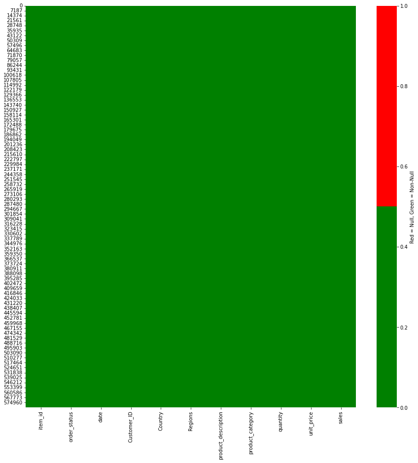

```python
cols = Df8.columns[:12]
colours = ['green', 'red']      # specify the colours - red is missing. blue is not missing.

plt.subplots(figsize=(15,15))  # magnify the plot size to view the details

sb.heatmap(Df8[cols].isnull(), cmap=sb.color_palette(colours), cbar_kws={'label': 'Red = Null, Green = Non-Null', 'orientation': 'vertical'})
# plotting as heatmap for null values, with colormap following your specified colors, set cbar arguments
plt.xticks(rotation=90)
plt.show()
```

```python
Df8.to_csv('eCommerceAnalysis_Df8_Group1_r01.csv', index=False)

print("Dataframe 8:")
Df8
```

```
Dataframe 8:
```

|  | item_id | order_status | date | Customer_ID | Country | Regions | product_description | product_category | quantity | unit_price | sales |
| --- | --- | --- | --- | --- | --- | --- | --- | --- | --- | --- | --- |
| 0 | 211131 | complete | 7/1/2016 | 1 | Australia | Oceania | kreations_YI 06-L | Women's Fashion | 1 | 11.63 | 11.63 |
| 1 | 211133 | canceled | 7/1/2016 | 2 | Australia | Oceania | kcc_Buy 2 Frey Air Freshener & Get 1 Kasual Bo... | Beauty & Grooming | 1 | 1.43 | 1.43 |
| 2 | 324257 | canceled | 11/25/2016 | 2 | Australia | Oceania | RS_Habshi Halwa Tin | Soghaat | 1 | 1.61 | 1.61 |
| 3 | 211134 | canceled | 7/1/2016 | 3 | Australia | Oceania | Ego_UP0017-999-MR0 | Women's Fashion | 1 | 14.62 | 14.62 |
| 4 | 473369 | complete | 5/19/2017 | 3 | Australia | Oceania | BT_BT-422 | Men's Fashion | 1 | 3.16 | 3.16 |
| ... | ... | ... | ... | ... | ... | ... | ... | ... | ... | ... | ... |
| 582063 | 904365 | received | 8/25/2018 | 115185 | Belgium | Europe | HASQAR5A744999A7B52 | Health & Sports | 1 | 0.79 | 0.79 |
| 582064 | 904607 | canceled | 8/26/2018 | 115222 | Belgium | Europe | BAGTRA5A0C12CBAC37B | Beauty & Grooming | 1 | 5.37 | 5.37 |
| 582065 | 904608 | canceled | 8/26/2018 | 115222 | Belgium | Europe | BAGROM5AAF9D112383E | Beauty & Grooming | 1 | 5.96 | 5.96 |
| 582066 | 904796 | canceled | 8/27/2018 | 115259 | Belgium | Europe | MATNOK5B2B7E715DF70 | Mobiles & Tablets | 1 | 29.83 | 29.83 |
| 582067 | 904987 | holded | 8/27/2018 | 115296 | Belgium | Europe | ENTCHA5B6A8FEA10D06 | Entertainment | 1 | 160.98 | 160.98 |

582068 rows × 11 columns